# Inaction on climate change projected to cost one year of life in some European countries

1. Import the underlying Forzieri et al data.
2. Import the Standard European Population from EuroStat.
3. Import the leading causes of death with age-standardized death rates from EuroStat.
4. Import the Global Burden of Disease data. This data is located on github.
5. Download all of the Human Mortality Database data.

To successfully run this code, several R packages must be installed and these packages are located just below this text section but are tidyverse, HMHFDplus, tmap, tmaptools, RColorBrewer, data.table, and getPass.

To successfully run this code, you must also have an account at the HMD and input your username and password when prompted.

```r
rm(list=ls())
library(tidyverse)
library(HMDHFDplus)
library(tmap)
library(tmaptools)
library(RColorBrewer)
library(data.table)
library(getPass)
###   Inputting user info for HMD
myusername <- getPass(msg = "HMD username: ", noblank = FALSE, forcemask = TRUE)
```

```
## Please enter password in TK window (Alt+Tab)
```

```r
mypassword <- getPass(msg = "HMD password: ", noblank = FALSE, forcemask = FALSE)
```

```
## Please enter password in TK window (Alt+Tab)
```

```r
###   Importing the data from Forizeri et al.
lancetdata <- tribble(
    ~CNTRY,  ~MID,  ~LOW, ~HIGH,
     "AUT",   467,   121,   797,
     "BEL",  2841,    91,  5007,
     "BGR",    44,    36,    63,
     "CHE",  1981,   497,  3247,
     "CYP",   143,    62,   279,
     "CZE",   375,    48,   628,
  "DEUTNP",  7319,   620, 12132,
     "DNK",    24,     4,    56,
     "EST",    12,     0,    22,
     "ESP", 41326, 33495, 53802,
     "FIN",    23,     3,    44,
  "FRATNP", 38728, 14235, 72947,
     "GRC",  2838,  1520,  5606,
     "HRV",  1145,   624,  1811,
     "HUN",   559,   191,   985,
     "IRL",  1566,   476,  4195,
     "ISL",     3,     1,     5,
     "ITA", 41965, 23694, 57401,
     "LTU",    15,     1,    25,
     "LUX",   392,    12,   820,
     "LVA",    17,     1,    30,
     "MLT",     0,     0,     0,
     "NLD",  1984,   126,  4114,
     "NOR",    15,     4,    34,
     "POL",   313,    52,   561,
     "PRT",  4573,  3808,  6284,
     "ROU",   177,    97,   301,
     "SWE",    52,    10,   113,
     "SVN",   561,   251,   847,
     "SVK",    63,    17,   118,
  "GBR_NP",  2515,   388,  7484
  )

### European Standard Population from EuroStat
ec_agestandard <- tribble(
  ~Age, ~StnrdPop,
     0,  1118.427,
     1,  4338.143,
     5,  5207.188,
    10,   5378.67,
    15,   6095.53,
    20,  6646.578,
    25,  7054.462,
    30,  7211.366,
    35,  7249.137,
    40,  7288.966,
    45,  7207.381,
    50,  6904.728,
    55,  6400.144,
    60,  5798.191,
    65,  4660.589,
    70,   4031.35,
    75,  3292.724,
    80,  4116.422
  )

### COD standardized death rates from EuroStat
europe_standarddr <- tribble(
          ~COUNTRY, ~Circulatorydisease, ~Cancer, ~Heartdisease, ~LungCancer, ~Respiratorydiseases, ~Diseasesofthenervoussystem, ~Colorectalcancer, ~Suicide, ~TransportAccidents,
           "EU-28",               373.6,   261.5,         126.3,        54.4,                 78.3,                        38.6,              30.5,     11.3,                 5.8,
      "Luxembourg",               296.9,   260.7,          80.3,        59.6,                 63.8,                          38,              25.5,     13.4,                   6,
           "Spain",                 245,   232.7,          68.2,        47.8,                 91.7,                        48.5,              33.6,      8.2,                 4.3,
           "Italy",               310.1,   246.6,          98.3,        49.4,                 58.3,                        34.3,                27,      6.3,                 5.6,
          "France",               202.9,   245.4,          49.3,        50.1,                   52,                        50.2,              26.1,     14.1,                 5.1,
        "Portugal",               305.8,   242.1,          69.6,        36.4,                116.7,                        32.8,                35,     11.3,                 7.8,
         "Croatia",               678.6,   336.4,         306.5,        65.2,                 59.7,                        21.3,                51,     16.8,                 8.9,
         "Ireland",               309.9,   288.3,         147.5,        61.5,                125.9,                        48.7,              32.4,       11,                   4,
        "Slovenia",               451.3,   299.9,         102.8,        58.6,                 66.3,                        21.1,              38.4,     18.9,                 6.7,
     "Switzerland",                 280,   219.6,          97.8,        42.1,                 51.3,                        44.5,              22.8,     12.8,                 3.6,
         "Belgium",               281.9,   252.6,          72.4,        61.6,                 95.7,                        46.5,              26.1,     17.3,                 6.7,
          "Greece",               381.4,   249.3,           103,        61.9,                108.1,                        20.9,              23.3,        5,                 8.6,
     "Netherlands",               271.7,   282.2,          62.4,        66.7,                 74.1,                        48.3,              32.9,     11.1,                 4.1,
         "Germany",               403.5,   253.2,         142.8,          51,                   68,                        29.6,                29,     11.9,                 4.6,
   "Great Britain",               264.9,   278.4,         118.4,        61.4,                130.9,                        47.6,              27.7,      7.1,                 2.8,
         "Austria",               418.1,   249.3,         179.1,        47.5,                 46.6,                        32.6,              26.4,     15.3,                 5.8,
        "Bulgaria",                1131,   242.4,         195.4,        45.5,                 58.1,                        15.3,              34.9,      9.9,                   9,
  "Czech Republic",               615.2,   284.6,         333.1,        53.1,                 73.4,                        30.8,              37.9,     14.4,                78.8,
         "Denmark",               256.6,   300.6,            81,        71.7,                115.7,                        42.9,              35.2,     11.9,                   4,
         "Estonia",               699.6,   299.4,         295.5,        55.3,                 43.8,                        21.8,                36,     18.3,                 7.5,
         "Finland",               378.8,   218.6,         199.2,          39,                 34.4,                         155,              22.6,     14.6,                 5.7,
         "Hungary",               761.5,   348.1,         390.6,        89.8,                 78.6,                        19.9,                55,     19.4,                 8.1,
          "Latvia",               882.7,   299.3,         442.7,        46.9,                 35.9,                        15.6,              34.2,       19,                12.4,
       "Lithuania",               848.8,   276.2,         564.4,        46.1,                 42.1,                        20.8,              32.1,     31.5,                10.7,
          "Norway",               272.6,   252.5,          95.7,        50.5,                 88.4,                        45.4,              36.4,      7.3,                   4,
          "Poland",               591.4,   292.3,         129.1,        69.2,                 69.1,                        16.5,                36,     15.5,                10.3,
        "Slovakia",               654.6,   324.1,         388.8,          50,                 74.9,                        29.5,              49.2,     10.8,                 8.5,
          "Sweden",               338.3,   234.8,         131.2,        38.7,                 58.1,                        42.6,              29.2,     12.1,                 3.4,
          "Cyprus",               351.8,     201,         108.7,        37.2,                 86.2,                        26.8,              16.7,      4.5,                 6.5,
   "Liechtenstein",               296.4,     203,          73.7,        31.3,                 89.8,                        67.6,               6.8,     10.2,                10.3,
           "Malta",               372.4,   233.5,         202.8,        43.2,                 96.6,                          21,              28.3,      8.3,                 2.5,
         "Romania",               951.3,   273.2,         320.3,        54.2,                 78.4,                          21,              32.4,     11.4,                12.3,
          "Serbia",               931.6,   298.3,         159.5,        69.4,                 79.7,                        27.3,              37.2,     15.9,                 7.6
  )

countrycodes <- read.csv("https://raw.githubusercontent.com/lukes/ISO-3166-Countries-with-Regional-Codes/master/all/all.csv") %>%
  rename(CNTRY = alpha.3,
         COUNTRY = name) %>%
  mutate(ISO3 = CNTRY) %>%
  select(COUNTRY, CNTRY, ISO3)

###   Getting a country list from the HMD
Countries <- getHMDcountries()

###   Downloading the DEATHS data from the HMD in 5-year age groups by single-year.
deaths <- rbindlist(lapply(Countries, function(CNTRY){
  Dat <- readHMDweb(CNTRY = CNTRY, item = "Deaths_5x1", fixup=TRUE, username = myusername, password = mypassword)
  Dat$CNTRY <- CNTRY
  Dat}))

###   Downloading the POPULATION data from the HMD.
pops <- rbindlist(lapply(Countries, function(CNTRY){
  Dat <- readHMDweb(CNTRY = CNTRY, item = "Population", fixup=TRUE, username = myusername, password = mypassword)
  Dat$CNTRY <- CNTRY
  Dat}))

###   Downloading the LIFE TABLE data from the HMD in 5-year age groups by single-year.
lt <- rbindlist(lapply(Countries, function(CNTRY){
  Dat <- readHMDweb(CNTRY = CNTRY, item = "bltper_5x1", fixup=TRUE, username = myusername, password = mypassword)
  Dat$CNTRY <- CNTRY
  Dat}))

###   Topcoding the age groups to 80+ of the LIFE TABLE data, and summing the ax value.
lt2 <- lt%>%
  mutate(Age = ifelse(Age >= 80, 80, Age)) %>%
  group_by(CNTRY, Year, Age)%>%
  summarise(ax = sum(ax))
###   Topcoding the age groups of the DEATHS data and summing.
deaths2 <- deaths %>%
  mutate(Age = ifelse(Age >=80, 80, Age)) %>%
  group_by(CNTRY, Year, Age) %>%
  summarise(deaths = sum(Total) )

###   Recoding the Population data to single year of age
pops2 <- pops %>%
  mutate(Age = case_when(
    Age >= 80 ~ 80,
    Age >= 75 ~ 75,
    Age >= 70 ~ 70,
    Age >= 65 ~ 65,
    Age >= 60 ~ 60,
    Age >= 55 ~ 55,
    Age >= 50 ~ 50,
    Age >= 45 ~ 45,
    Age >= 40 ~ 40,
    Age >= 35 ~ 35,
    Age >= 30 ~ 30,
    Age >= 25 ~ 25,
    Age >= 20 ~ 20,
    Age >= 15 ~ 15,
    Age >= 10 ~ 10,
    Age >= 5 ~5,
    Age >= 1 ~ 1,
    TRUE ~ as.numeric(Age)
  ))  %>%
  group_by(CNTRY, Year, Age) %>%
  summarise(Pop= sum(Total1))

###   Joining the POPULATION, DEATHS, and LIFE TABLE data and subseting to the maximum year in the data.
a <- left_join(pops2, deaths2)
a <- left_join(a, lt2)
```

```r
a <- group_by(a, CNTRY, Age) %>%
  filter(Year == max(Year))

###   Importing the GBD data.
###   Data is 5-year age groups of mortality rates for Environmental heat and cold exposure for 2006-2015.
###   Analysis uses the mean of the last 10 years of data for this death distribution.
GBD_data <- read.csv("data/GBD_data.csv") %>%
  #mutate(perdist = log(val)) %>%
  group_by(countrycode, Age) %>%
  summarise(meanval = mean(val),
            upperval = mean(upper),
            lowerval = mean(lower)) %>%
  group_by(countrycode) %>%
  mutate(countmeanval = sum(meanval),
         countupperval = sum(upperval),
         countlowerval = sum(lowerval),
         perdist = (meanval / countmeanval)) %>%
  rename(CNTRY = countrycode)

################################
#
# MAKING THE LIFE TABLES
#
################################
a <-  left_join(a, lancetdata)  %>%
  select(Age, Pop, CNTRY, deaths, ax, MID, LOW, HIGH) %>%
  filter(!is.na(MID))
a2 <- left_join(a, GBD_data) %>%
  mutate(width = ifelse(Age == 0, 1,
                        ifelse(Age == 1, 4,5)),
         mx_base = deaths/Pop,
         mx_low = (deaths + LOW * perdist)/Pop,
         mx_mid = (deaths + MID * perdist)/Pop,
         mx_high = (deaths + HIGH * perdist)/Pop,
         qx_base = ifelse(Age == 80, 1, mx_base/(1+((width-ax)*mx_base))),
         qx_low = ifelse(Age == 80, 1, mx_low/(1+((width-ax)*mx_low))),
         qx_mid = ifelse(Age == 80, 1, mx_mid/(1+((width-ax)*mx_mid))),
         qx_high = ifelse(Age == 80, 1, mx_high/(1+((width-ax)*mx_high)))) %>%
  group_by(CNTRY) %>%
  mutate(lx_base = ifelse(is.na(lag(cumprod(1-qx_base),1)*100000), 100000, lag(cumprod(1-qx_base),1)*100000),
         dx_base = qx_base*lx_base,
         Lx_base = ifelse(Age == 80, (lx_base/mx_base), ax * lx_base + (width-ax) * lead(lx_base,1)),
         Tx_base = rev(cumsum(rev(Lx_base))),
         ex_base = Tx_base/lx_base,
         lx_low = ifelse(is.na(lag(cumprod(1-qx_low),1)*100000), 100000, lag(cumprod(1-qx_low),1)*100000),
         dx_low = qx_low*lx_low,
         Lx_low = ifelse(Age == 80, (lx_low/mx_low), ax * lx_low + (width-ax) * lead(lx_low,1)),
         Tx_low = rev(cumsum(rev(Lx_low))),
         ex_low = Tx_low/lx_low,
         lx_mid = ifelse(is.na(lag(cumprod(1-qx_mid),1)*100000), 100000, lag(cumprod(1-qx_mid),1)*100000),
         dx_mid = qx_mid*lx_mid,
         Lx_mid = ifelse(Age == 80, (lx_mid/mx_mid), ax * lx_mid + (width-ax) * lead(lx_mid,1)),
         Tx_mid = rev(cumsum(rev(Lx_mid))),
         ex_mid = Tx_mid/lx_mid,
         lx_high = ifelse(is.na(lag(cumprod(1-qx_high),1)*100000), 100000, lag(cumprod(1-qx_high),1)*100000),
         dx_high = qx_high*lx_high,
         Lx_high = ifelse(Age == 80, (lx_high/mx_high), ax * lx_high + (width-ax) * lead(lx_high,1)),
         Tx_high = rev(cumsum(rev(Lx_high))),
         ex_high = Tx_high/lx_high,
         DIF_LOW = ex_low - ex_base,
         DIF_MID = ex_mid - ex_base,
         DIF_HIGH = ex_high - ex_base)
lt_lancet <- a2 %>%
  filter(Age == 0) %>%
  mutate(Base_e0 = ex_base,
         LOW_e0 = ex_low,
         MID_e0 = ex_mid,
         HIGH_e0 = ex_high) %>%
  dplyr::select(CNTRY, Base_e0, LOW_e0, MID_e0, HIGH_e0, DIF_LOW, DIF_MID, DIF_HIGH) %>%
  ungroup() %>%
  arrange(DIF_MID) %>%
  mutate(RANK = row_number(),
         dif_mid = round(DIF_MID, 2)) %>%
  left_join(., countrycodes) %>%
  mutate(COUNTRY = case_when(
    CNTRY == "FRATNP" ~ "France",
    CNTRY == "DEUTNP" ~ "Germany",
    CNTRY == "GBR_NP" ~ "Great Britain",
    TRUE ~ as.character(COUNTRY)),
    ISO3 = case_when(
      CNTRY == "FRATNP" ~ "FRA",
      CNTRY == "DEUTNP" ~ "DEU",
      CNTRY == "GBR_NP" ~ "GBR",
      TRUE ~ as.character(ISO3)),
    Test = ISO3)
```

# Figure 1

This chunk of code reproduces Figure 1.

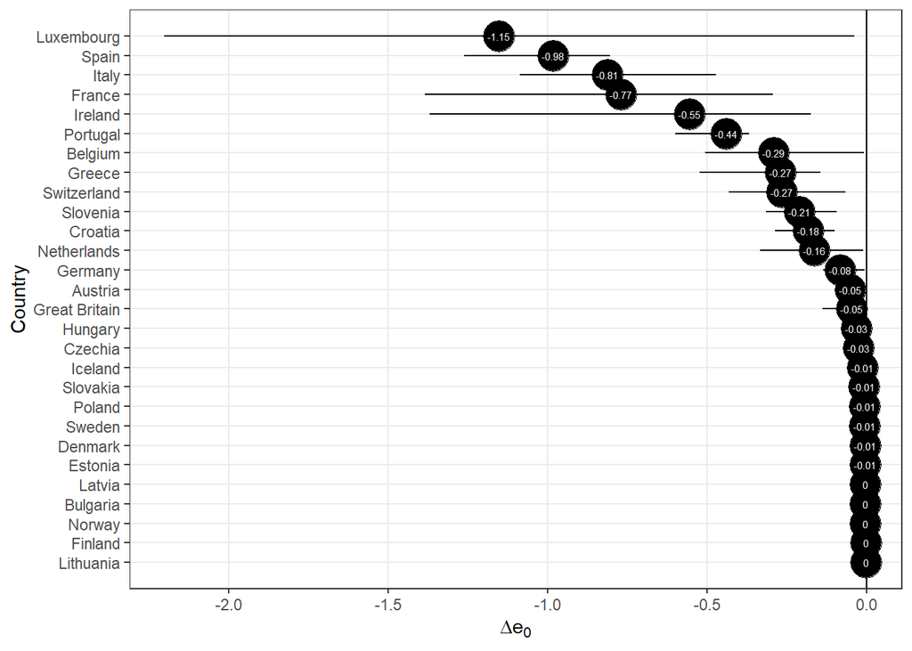

```r
ggplot(lt_lancet, aes(x=RANK, y=DIF_MID, ymin = DIF_LOW, ymax = DIF_HIGH, label=dif_mid)) +
  geom_pointrange(stat="identity") +
  geom_point(stat="identity", fill="black", size=8) +
   geom_hline(yintercept=0) +
  geom_text(color="white", size=2) +
  #scale_x_discrete(limits = rev(levels(the_factor)))
  scale_x_reverse(breaks = lt_lancet$RANK, labels=lt_lancet$COUNTRY) +
  coord_flip() +
  theme_bw() +
  #ylim(-2, 2) +
  theme(panel.grid.minor = element_blank()) +

   labs(y=expression(Delta* e[0]),
        x= "Country")
```

# Figure 2

This chunk of code reproduecs Figure 2.

```r
load("DATA/Europe.rda")
Europe2 <- append_data(Europe, lt_lancet, key.shp = "iso_a3", key.data = "ISO3", ignore.na = TRUE)
```

```
## Europe key variable "iso_a3" contains NA's, which are ignored
```

```
## Under coverage: 40 out of 68 shape features did not get appended data. Run under_coverage() to get the corresponding feature id numbers and key values.
```

```r
bbeur <- bb(Europe2, xlim = c(0,0.75), ylim=c(0,1), relative = TRUE)

  tm_shape(Europe2) +
  tm_fill("DIF_MID", title = expression(Delta* e[0 ~italic(MID)]), palette = "YlOrBr", style = "jenks") +
  tm_borders(alpha = 0.5) +
  tm_text("Test" , size="AREA", root=5) +
  tm_format_Europe()
```

[figure not shown]

# Supplementay Figure 1

This chunk of code reproduces the Supplementary Figure

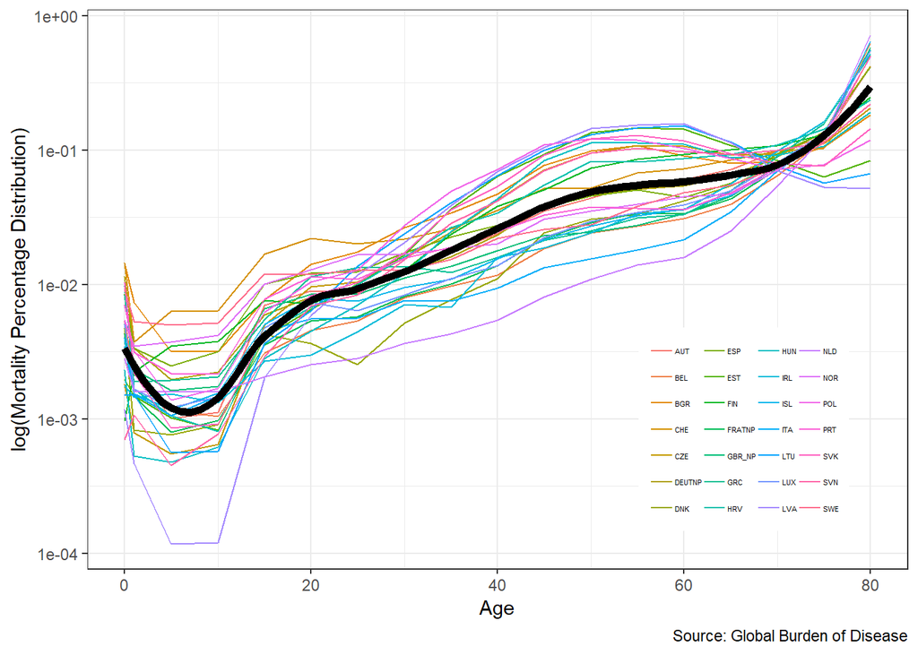

```r
GBD_data <- read.csv("data/GBD_data.csv") %>%
  #mutate(perdist = log(val)) %>%
  group_by(countrycode, Age) %>%
  summarise(meanval = mean(val),
            upperval = mean(upper),
            lowerval = mean(lower)) %>%
  group_by(countrycode) %>%
  mutate(countmeanval = sum(meanval),
         countupperval = sum(upperval),
         countlowerval = sum(lowerval),
         perdist = (meanval / countmeanval)) %>%
  rename(CNTRY = countrycode)

ggplot(data=GBD_data, aes(x=Age, y=perdist)) +
  geom_line(aes(color=CNTRY), alpha=1) +
  geom_smooth(span=0.3, se=F, col="black", lwd =2) +
  theme_bw() +
  theme(legend.position = c(0.8,0.25),
        legend.title=element_blank(),
        legend.text=element_text(size=4),
        legend.key.size = unit(1,"line")) +
  guides(col = guide_legend(ncol = 4)) +
  scale_y_log10()+
  labs(y="log(Mortality Percentage Distribution)",
       #title = "Mortality distribution of Heat-related mortality in 28 European countries",
       caption = "Source: Global Burden of Disease")
```

# Table 1

This chunk of code reproduces the data inside Table 1 in the main document.

Note: the output from this table (the object testtbl) is formatted for latex rather than markdown. To completely reproduce that table, the output from testtbl must be pasted into a latex compiler and all forward slashes (“/”) must be converted to backward slashes ("").

```r
standard <- left_join(a2, ec_agestandard) %>%
  left_join(., countrycodes) %>%
  select(Age, CNTRY, COUNTRY, mx_base, mx_low, mx_mid, mx_high, StnrdPop) %>%
  mutate(ASDR_base = mx_base * StnrdPop,
         ASDR_low = mx_low * StnrdPop,
         ASDR_mid = mx_mid * StnrdPop,
         ASDR_high = mx_high * StnrdPop) %>%
  group_by(CNTRY, COUNTRY) %>%
  summarise(ASDR_base = sum(ASDR_base),
            ASDR_low = sum(ASDR_low),
            ASDR_mid = sum(ASDR_mid),
            ASDR_high = sum(ASDR_high)) %>%
  mutate(ASDR_low = ASDR_low - ASDR_base,
         ASDR_mid = ASDR_mid - ASDR_base,
         ASDR_high = ASDR_high - ASDR_base,
         COUNTRY = case_when(
           CNTRY == "FRATNP" ~ "France",
           CNTRY == "DEUTNP" ~ "Germany",
           CNTRY == "GBR_NP" ~ "Great Britain",
           TRUE ~ as.character(COUNTRY))) %>%
  left_join(., europe_standarddr) %>%
  ungroup() %>%
  select(-ASDR_base, -CNTRY)
selectcountries <- c("Spain", "Luxembourg", "Italy", "France", "Portugal", "Ireland", "Slovenia", "Croatia", "Switzerland", "Belgium")
testtbl<- standard %>%
  group_by(COUNTRY) %>%
  gather(COD, ASDR, 2:13) %>%
  filter(!COD %in% c("Circulatorydisease", "Cancer", "ASDR_high", "ASDR_low"),
         !COUNTRY == "Iceland") %>%
  mutate(RANK = rank(desc(ASDR)),
         ASDR = round(ASDR,2),
         COD = case_when(
           COD == "Heartdisease" ~ "makecell{Heart\\Disease\\",
           COD == "LungCancer" ~ "makecell{Lung\\Cancer\\",
           COD == "Respiratorydiseases" ~ "makecell{Respiratory\\Diseases\\",
           COD == "Diseasesofthenervoussystem" ~ "makecell{Dis. of the\\Nervous Sys\\",
           COD == "Colorectalcancer" ~ "makecell{Colorectal\\Cancer\\",
           COD == "Suicide" ~ "makecell{Suicide\\",
           COD == "TransportAccidents" ~ "makecell{Transport\\Accidents\\",
           COD == "ASDR_mid"  ~ "cellcolor{blue!25}makecell{cellcolor{blue!25}Climate\\cellcolor{blue!25}Change\\cellcolor{blue!25}"),
         Value = paste0(COD, " ", ASDR, "}")) %>%
  ungroup()%>%
  arrange(COD, desc(ASDR)) %>%
  #mutate(COUNTRY = paste0(row_number(),COUNTRY))%>%
  select(COUNTRY, Value, RANK) %>%
  spread(RANK, Value) %>%
  slice(match(selectcountries, COUNTRY))

head(testtbl)
```

| COUNTRY | 1 | 2 | 3 | 4 | 5 | 6 | 7 | 8 |
| --- | --- | --- | --- | --- | --- | --- | --- | --- |
| Spain | makecell{Respiratory\\Diseases\\ 91.7} | cellcolor{blue!25}makecell{cellcolor{blue!25}Climate\\cellcolor{blue!25}Change\\cellcolor{blue!25} 76.24} | makecell{Heart\\Disease\\ 68.2} | makecell{Dis. of the\\Nervous Sys\\ 48.5} | makecell{Lung\\Cancer\\ 47.8} | makecell{Colorectal\\Cancer\\ 33.6} | makecell{Suicide\\ 8.2} | makecell{Transport\\Accidents\\ 4.3} |
| Luxembourg | makecell{Heart\\Disease\\ 80.3} | cellcolor{blue!25}makecell{cellcolor{blue!25}Climate\\cellcolor{blue!25}Change\\cellcolor{blue!25} 76.93} | makecell{Respiratory\\Diseases\\ 63.8} | makecell{Lung\\Cancer\\ 59.6} | makecell{Dis. of the\\Nervous Sys\\ 38} | makecell{Colorectal\\Cancer\\ 25.5} | makecell{Suicide\\ 13.4} | makecell{Transport\\Accidents\\ 6} |
| Italy | makecell{Heart\\Disease\\ 98.3} | makecell{Respiratory\\Diseases\\ 58.3} | cellcolor{blue!25}makecell{cellcolor{blue!25}Climate\\cellcolor{blue!25}Change\\cellcolor{blue!25} 49.87} | makecell{Lung\\Cancer\\ 49.4} | makecell{Dis. of the\\Nervous Sys\\ 34.3} | makecell{Colorectal\\Cancer\\ 27} | makecell{Suicide\\ 6.3} | makecell{Transport\\Accidents\\ 5.6} |
| France | makecell{Respiratory\\Diseases\\ 52} | makecell{Dis. of the\\Nervous Sys\\ 50.2} | makecell{Lung\\Cancer\\ 50.1} | makecell{Heart\\Disease\\ 49.3} | cellcolor{blue!25}makecell{cellcolor{blue!25}Climate\\cellcolor{blue!25}Change\\cellcolor{blue!25} 49.14} | makecell{Colorectal\\Cancer\\ 26.1} | makecell{Suicide\\ 14.1} | makecell{Transport\\Accidents\\ 5.1} |
| Portugal | makecell{Respiratory\\Diseases\\ 116.7} | makecell{Heart\\Disease\\ 69.6} | makecell{Lung\\Cancer\\ 36.4} | cellcolor{blue!25}makecell{cellcolor{blue!25}Climate\\cellcolor{blue!25}Change\\cellcolor{blue!25} 35.95} | makecell{Colorectal\\Cancer\\ 35} | makecell{Dis. of the\\Nervous Sys\\ 32.8} | makecell{Suicide\\ 11.3} | makecell{Transport\\Accidents\\ 7.8} |
| Ireland | makecell{Heart\\Disease\\ 147.5} | makecell{Respiratory\\Diseases\\ 125.9} | makecell{Lung\\Cancer\\ 61.5} | makecell{Dis. of the\\Nervous Sys\\ 48.7} | cellcolor{blue!25}makecell{cellcolor{blue!25}Climate\\cellcolor{blue!25}Change\\cellcolor{blue!25} 44.65} | makecell{Colorectal\\Cancer\\ 32.4} | makecell{Suicide\\ 11} | makecell{Transport\\Accidents\\ 4} |